# Creating custom *steps* functions

Casey Visintin

2021-02-16

Perhaps one of the most useful features of *steps* is its flexibility. Users have the options of selecting pre-defined functions or writing their own functions to use in simulations. This vignette will describe how to implement custom functions in the *steps* software.

First, we load required packages:

```r
library(steps)
library(raster)
library(viridisLite)
library(future)
```

Landscape objects contain information on populations, carrying capacities, habitat features, and other spatially-explicit information used by dynamic functions in a simulation. Dynamics functions act on these landscape objects during a simulation.

Let’s examine a pre-built *steps* dynamics function “mortality” which changes populations based on spatially-explicit values provided in a raster layer.

```r
mortality <- function (mortality_layer, stages = NULL) {

  pop_dynamics <- function (landscape, timestep) {

      population_raster <- landscape$population
      nstages <- raster::nlayers(population_raster)

      # get population as a matrix
      idx <- which(!is.na(raster::getValues(population_raster[[1]])))
      population_matrix <- raster::extract(population_raster, idx)

      mortality_prop <- raster::extract(landscape[[mortality_layer]][[timestep]], idx)

      if (is.null(stages)) stages <- seq_len(nstages)

      for (stage in stages) {

        population_matrix[ , stage] <- ceiling(population_matrix[ , stage] * mortality_prop)

      }

      # put back in the raster
      population_raster[idx] <- population_matrix

      landscape$population <- population_raster


    landscape

  }

  as.population_modification(pop_dynamics)

}
```

In the first statement, we have defined a function with parameters that specify the name of the layer in the landscape object that will be used to modify populations (mortality_layer) and which life stages will be modified (stages). We have set “stages” to NULL as a default so, if not specified, all stages will be modified. These are global parameters for the function and are optional.

We define an internal function (returned by the main function) in the second statement and this is where the dynamic operations are specified. Note the two parameters are “landscape” and “timestep” and these are both required.

The next few statements operate on the landscape object by extracting the populations of the affected stages, extracting the values of the “mortality layer”, multiplying them to get new populations, and then returning the modified populations to the landscape object. Note the last statement is always “landscape” so the landscape object is returned when the function concludes its operations.

The final statement assigns a class to the function. This is optional but useful to maintain an organised structure in the software. We recommend using the appropriate function based on the category of the function a user is defining. In this case, this function is a “population_modification” class since its operations change the population in the landscape object.

So let’s go about creating a custom function for use in *steps*. First, we load some initial kangaroo populations:

```r
egk_pop
```

```
## class      : RasterStack
## dimensions : 35, 36, 1260, 3  (nrow, ncol, ncell, nlayers)
## resolution : 500, 500  (x, y)
## extent     : 319000, 337000, 5817000, 5834500  (xmin, xmax, ymin, ymax)
## crs        : +proj=utm +zone=55 +south +ellps=GRS80 +towgs84=0,0,0,0,0,0,0 +units=m +no_defs
## names      : juvenile, subadult, adult
## min values :        1,        1,     1
## max values :       20,       20,    20
```

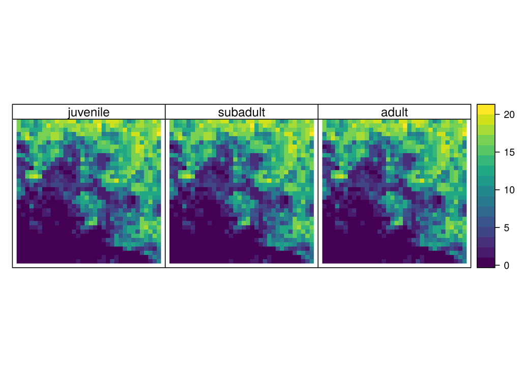

```r
par(mar=c(0,0,0,0), oma=c(0,0,0,0))
spplot(egk_pop,
       col.regions = viridis(100),
       par.settings=list(strip.background = list(col = "white")))
```

Let’s examine the total population of juveniles:

```r
cellStats(egk_pop[[1]], sum)
```

```
## [1] 9066
```

Now, let’s create a function that reduces cell populations randomly across the landscape by a given percentage for the life stages specified. We start with the first two lines coded similar to the previous example and change the function name and one of the parameters:

```r
percent_mortality <- function (percentage, stages = NULL) {

  pop_dynamics <- function (landscape, timestep) { ...
```